# Final Project

Cody Liu 919431964

2024-03-14

# Abstract

We are working with 18 sessions (datasets) derived from measurements taken of the neural pathways of 4 mice using neuropixel probes conducted in the research of Nicholas A Steinmetz. The probes were able to record 30,000 neurons in ~40 areas within the brains of the mice. The experiment was conducted on 10 mice over 39 sessions; 18 of these sessions are analyzed in the following report. The mice were stimulated with visual stimuli. The stimuli prompted each mouse was then prompted to make a decision to move a wheel in a certain direction. A penalty and reward system was was employed to condition the mice to produce the desired outcome. The following analysis aims to build a predictive model that allows us to infer the outcome of future sessions based on the data we have recieved about these mice. This will be done via conducting an exploratory data analysis on the 18 sessions; in the EDA we will note the differences between the trials. The data will then be integrated in order to discover patterns between the sessions. The appropriate predictive models will then be trained and benchmarked to determine the most effective for future application.

# Introduction

The dataset is derived from the research of Nicholas A Steinmetz. 18 of 39 sessions conducted on 4 of 10 mice will be analyzed in the report.

The key variables for each trial ,include:

- feedback_type: The type of feedback given. This is a binary variable that is either 1 or -1
- left_contrast: The contrast level of the left stimulus.
- right_contrast: The contrast level of the right stimulus.
- time: The center points of time bins for neuronal spikes.
- spks: The number of neuronal spikes in the visual cortex.
- brain_area: The specific region of the brain where the neuron is located.

We hypothesize that the number of neuronal spikes in the visual cortex of different mice will show a significant positive correlation in response to identical visual stimuli under controlled experimental conditions. Upon confirmation/rejection of this hypothesis there are additional questions of interest regarding the data:

- How does the intensity of neuronal activation vary between mice that accurately discriminate high-contrast visual stimuli from those that do not?
- Are there consistent neural firing patterns within individual mice across different sessions that correlate with their ability to learn and improve task performance over time?
- What is the relationship between the complexity of visual stimuli (e.g., varying contrasts and spatial frequencies) and the predictive accuracy of the model for different types of errors (e.g., contrast misjudgment versus spatial misalignment)?

# Background

Vision, choice, action, and behavioural engagement in mice involve neurons across various brain regions. Steinmetz’s group conducted a study to map the neuronal substrates related to these functions using neuropixel probes to record from 30,000 neurons across 42 brain regions. This method allowed for the analysis of the distribution of neurons involved in processing sensory information, selecting actions for rewards, and performing these actions. Prior research focused on regions like the frontal, parietal, and motor cortex, basal ganglia, thalamus, cerebellum, and superior colliculus. Observations show correlations between movements, rewards, and task variables in areas considered sensory, indicating action selection’s broader involvement. The study investigated the distribution of neurons related to these processes in the brain and if they use shared or distinct circuits.

# Exploratory Analysis

In our exploratory data analysis we will focus on four individual parts. We will attempt the describe the data structures accross sessions, explore the neural activities during each trial, explore the changes across trials, and explore homogenity and heterogenity across sessions and mice.

**Describe the Data Structures Across Sessions** - Number of Neurons and Trials: Find summary statistics in order to understand the distribution and number of neurons and trials across sessions. - Stimuli Conditions: Analyze distribution of contrast levels - Feedback Types: Assess distribution of feedback types

**Explore the Neural Activities During Each Trial**

**Explore Changes Across Trials** - Learning Effects - Neural Adaptation

**Explore Homogeneity and Heterogeneity Across Sessions and Mice** - Across sessions - Across Mice - Cluster Analysis

```r
knitr::opts_chunk$set(echo = TRUE)
options(repos = list(CRAN="http://cran.rstudio.com/"))

library(kableExtra)
library(magrittr)
library(tidyverse)
library(readr)
library(knitr)
library(dplyr)
library(factoextra)
library(caret)
library(xgboost)
library(pROC)
getwd()
```

```
## [1] "C:/General/Code/STA141A_Final_Project/STA141A_Final_Project"
```

# Data structure

Import data:

```r
session=list()
for(i in 1:18){
  session[[i]]=readRDS(paste('data/sessions/session',i,'.rds',sep=''))
}
n.session = length(session)
```

Figure 1: Session Level Loaded Dataframe

| mouse_name | date_exp | brain_area | neurons_spikes | trials | feedback_success_rate | avg_contrast_left | avg_contrast_right |
| --- | --- | --- | --- | --- | --- | --- | --- |
| Cori | 2016-12-14 | 8 | 734 | 114 | 0.61 | 0.30 | 0.43 |
| Cori | 2016-12-17 | 5 | 1070 | 251 | 0.63 | 0.32 | 0.35 |
| Cori | 2016-12-18 | 11 | 619 | 228 | 0.66 | 0.24 | 0.37 |
| Forssmann | 2017-11-01 | 11 | 1769 | 249 | 0.67 | 0.33 | 0.32 |
| Forssmann | 2017-11-02 | 10 | 1077 | 254 | 0.66 | 0.34 | 0.36 |
| Forssmann | 2017-11-04 | 5 | 1169 | 290 | 0.74 | 0.35 | 0.32 |
| Forssmann | 2017-11-05 | 8 | 584 | 252 | 0.67 | 0.29 | 0.33 |
| Hench | 2017-06-15 | 15 | 1157 | 250 | 0.64 | 0.44 | 0.38 |
| Hench | 2017-06-16 | 12 | 788 | 372 | 0.69 | 0.41 | 0.27 |
| Hench | 2017-06-17 | 13 | 1172 | 447 | 0.62 | 0.38 | 0.27 |
| Hench | 2017-06-18 | 6 | 857 | 342 | 0.80 | 0.33 | 0.31 |
| Lederberg | 2017-12-05 | 12 | 698 | 340 | 0.74 | 0.29 | 0.32 |
| Lederberg | 2017-12-06 | 15 | 983 | 300 | 0.80 | 0.36 | 0.30 |
| Lederberg | 2017-12-07 | 10 | 756 | 268 | 0.69 | 0.33 | 0.31 |
| Lederberg | 2017-12-08 | 8 | 743 | 404 | 0.76 | 0.34 | 0.33 |
| Lederberg | 2017-12-09 | 6 | 474 | 280 | 0.72 | 0.37 | 0.31 |
| Lederberg | 2017-12-10 | 6 | 565 | 224 | 0.83 | 0.32 | 0.39 |
| Lederberg | 2017-12-11 | 10 | 1090 | 216 | 0.81 | 0.32 | 0.30 |

```
## Session vars:
## contrast_left : numeric
## contrast_right : numeric
## feedback_type : numeric
## mouse_name : character
## brain_area : character
## date_exp : character
## spks : list
## time : list
```

```
## [1] "contrast_left unique values:"
## [1] 0.00 0.50 1.00 0.25
## contrast_left is not a binary variable.
## [1] "contrast_right unique values:"
## [1] 0.50 0.00 1.00 0.25
## contrast_right is not a binary variable.
## [1] "feedback_type unique values:"
## [1]  1 -1
## feedback_type is a binary variable with values -1 and 1.
```

Feedback_type is a binary variable with values -1 and 1. Contrast_left and Contrast right are both discrete variables with the following values: 0.00 0.25 0.50 1.00

Additionally the other variables listed denote the contents of a session within this dataset.

```r
df %>%
  summarise(Average_Neurons = mean(neurons_spikes),
            Median_Neurons = median(neurons_spikes),
            Average_Trials = mean(trials),
            Median_Trials = median(trials))
```

```
## # A tibble: 1 × 4
##   Average_Neurons Median_Neurons Average_Trials Median_Trials
##             <dbl>          <dbl>          <dbl>         <dbl>
## 1            906.           822.           282.           261
```

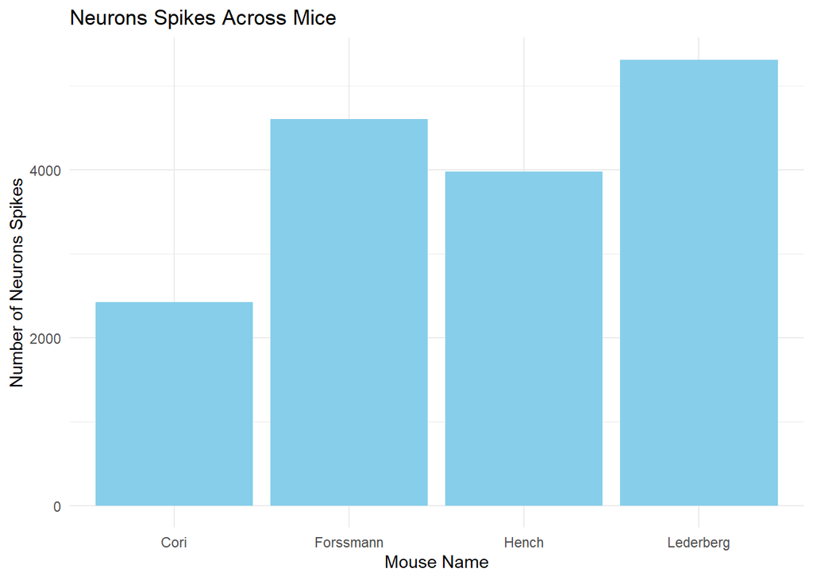

```r
ggplot(df, aes(x = mouse_name, y = neurons_spikes)) +
  geom_bar(stat = "identity", fill = "skyblue") +
  theme_minimal() +
  labs(title = "Neurons Spikes Across Mice", x = "Mouse Name", y = "Number of Neurons Spikes")
```

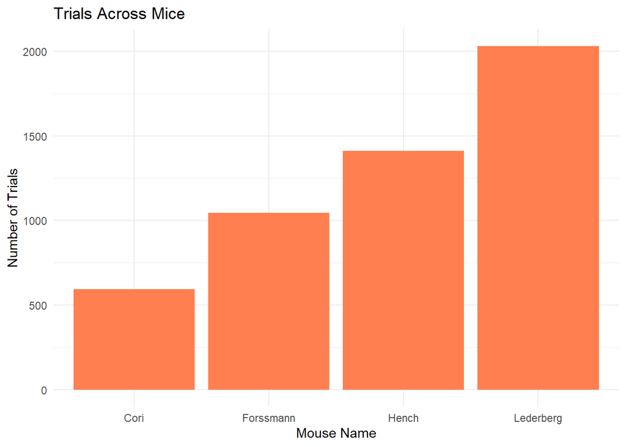

```r
ggplot(df, aes(x = mouse_name, y = trials)) +
  geom_bar(stat = "identity", fill = "coral") +
  theme_minimal() +
  labs(title = "Trials Across Mice", x = "Mouse Name", y = "Number of Trials")
```

Across sessions, we find that the median number of trials is 261.

```r
for(i in 1:length(session)) {
  cat("Number of neurons measured and observed in session", i, ":", nrow(session[[i]]$spks[[1]]), "\n")
}
```

```
## Number of neurons measured and observed in session 1 : 734
## Number of neurons measured and observed in session 2 : 1070
## Number of neurons measured and observed in session 3 : 619
## Number of neurons measured and observed in session 4 : 1769
## Number of neurons measured and observed in session 5 : 1077
## Number of neurons measured and observed in session 6 : 1169
## Number of neurons measured and observed in session 7 : 584
## Number of neurons measured and observed in session 8 : 1157
## Number of neurons measured and observed in session 9 : 788
## Number of neurons measured and observed in session 10 : 1172
## Number of neurons measured and observed in session 11 : 857
## Number of neurons measured and observed in session 12 : 698
## Number of neurons measured and observed in session 13 : 983
## Number of neurons measured and observed in session 14 : 756
## Number of neurons measured and observed in session 15 : 743
## Number of neurons measured and observed in session 16 : 474
## Number of neurons measured and observed in session 17 : 565
## Number of neurons measured and observed in session 18 : 1090
```

The number of neurons ,included in each session are above.

The number of neurons across trials within the same session is constant but the number of neurons across sessions differs.

**Trial Contents**

```
## [1] 734  40
```

```
## [1] 734
```

```
##  [1] 0 0 1 0 0 0 1 0 0 0 0 0 0 0 0 0 0 0 0 0 0 0 1 0 0 0 0 0 0 0 0 0 0 0 0 0 0 0
## [39] 0 0
```

**What brain areas are recorded in each session?**

```
## Session 1 brain areas:
## [1] "ACA"  "MOs"  "LS"   "root" "VISp" "CA3"  "SUB"  "DG"
##
## Session 2 brain areas:
## [1] "CA1"   "VISl"  "root"  "VISpm" "POST"
##
## Session 3 brain areas:
##  [1] "DG"    "VISam" "MG"    "CA1"   "SPF"   "root"  "LP"    "MRN"   "POST"
## [10] "NB"    "VISp"
##
## Session 4 brain areas:
##  [1] "LGd"  "DG"   "TH"   "SUB"  "VPL"  "VISp" "CA1"  "VISa" "LSr"  "ACA"
## [11] "MOs"
##
## Session 5 brain areas:
##  [1] "VISa" "root" "CA1"  "SUB"  "DG"   "OLF"  "ORB"  "ACA"  "PL"   "MOs"
##
## Session 6 brain areas:
## [1] "AUD"  "root" "SSp"  "CA1"  "TH"
##
## Session 7 brain areas:
## [1] "VPL"  "root" "CA3"  "LD"   "CP"   "EPd"  "SSp"  "PIR"
##
## Session 8 brain areas:
##  [1] "ILA"  "TT"   "MOs"  "PL"   "LSr"  "root" "LD"   "PO"   "CA3"  "VISa"
## [11] "CA1"  "LP"   "DG"   "VISp" "SUB"
##
## Session 9 brain areas:
##  [1] "TT"    "ORBm"  "PL"    "LSr"   "root"  "CA3"   "VISl"  "CA1"   "TH"
## [10] "VISam" "VPL"   "LD"
##
## Session 10 brain areas:
##  [1] "MB"    "VISp"  "SCm"   "SCsg"  "POST"  "DG"    "MRN"   "CA1"   "VISl"
## [10] "POL"   "root"  "GPe"   "VISrl"
##
## Session 11 brain areas:
## [1] "MOp"  "LSc"  "root" "PT"   "CP"   "LSr"
##
## Session 12 brain areas:
##  [1] "VISp"  "DG"    "SUB"   "LGd"   "PL"    "root"  "MOs"   "ACA"   "CA1"
## [10] "VISam" "MD"    "LH"
##
## Session 13 brain areas:
##  [1] "VISam" "ZI"    "DG"    "CA1"   "LGd"   "MB"    "SCs"   "RN"    "MRN"
## [10] "SCm"   "ACA"   "PL"    "MS"    "root"  "MOs"
##
## Session 14 brain areas:
##  [1] "ORB"  "MOs"  "root" "MRN"  "SCm"  "SCs"  "VISp" "RSP"  "CA1"  "PAG"
##
## Session 15 brain areas:
## [1] "BLA"  "GPe"  "root" "VPM"  "LGd"  "ZI"   "MB"   "CA3"
##
## Session 16 brain areas:
## [1] "SSs" "SSp" "MB"  "TH"  "LGd" "CA3"
##
## Session 17 brain areas:
## [1] "root" "VPL"  "VPM"  "RT"   "MEA"  "LD"
##
## Session 18 brain areas:
##  [1] "CP"   "ACB"  "OT"   "SI"   "SNr"  "LGd"  "ZI"   "CA3"  "root" "TH"
```

The above output shows us that each session examines different brain areas.

# Stimuli Conditions

To better understand stimuli conditions we take the average of the right and left contrasts to better understand the distribution of testing across both trials and sessions.

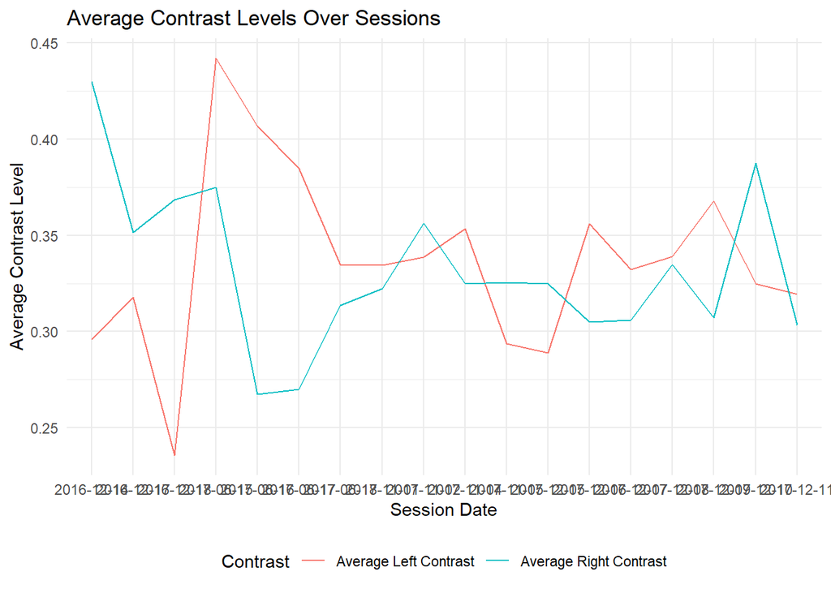

From this plot we notice that contrast levels across sessions differ greatly but range from ~0.24 to ~0.43 for both left and right average contrast levels.

# Feedback Types

To better understand the overall performance of the mice. We will plot the feedback success rate by session and mouse.

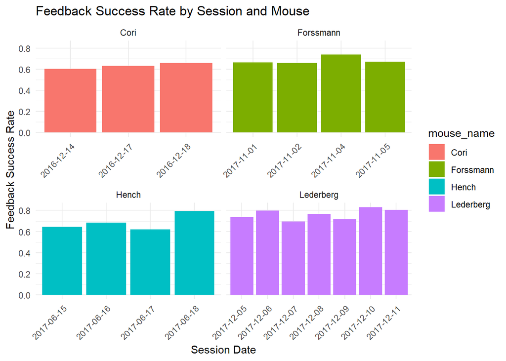

```r
df$date_exp <- as.factor(df$date_exp)

df %>%
  ggplot(aes(x = date_exp, y = feedback_success_rate, fill = mouse_name)) +
  geom_bar(stat = "identity", position = position_dodge()) +
  facet_wrap(~mouse_name, scales = "free_x") +
  labs(title = "Feedback Success Rate by Session and Mouse",
       x = "Session Date",
       y = "Feedback Success Rate") +
  theme_minimal() +
  theme(axis.text.x = element_text(angle = 45, hjust = 1))
```

Looking at this bar chart displaying the feedback success rate over time for each mouse it is quite apparent that all the mice performed better than random guessing (FSR>0.5). Lederberg is especially notable because of the mouse’s consistently high performance it holds high marks for consistently high FSR over time with Forssmann as a close second.

**Explore the Neural Activities During Each Trial**

Here we will need to load the data in again for individual sessions so that we can examine the nerual activities during each individual trial. We will then assess general neural engagement across trials.

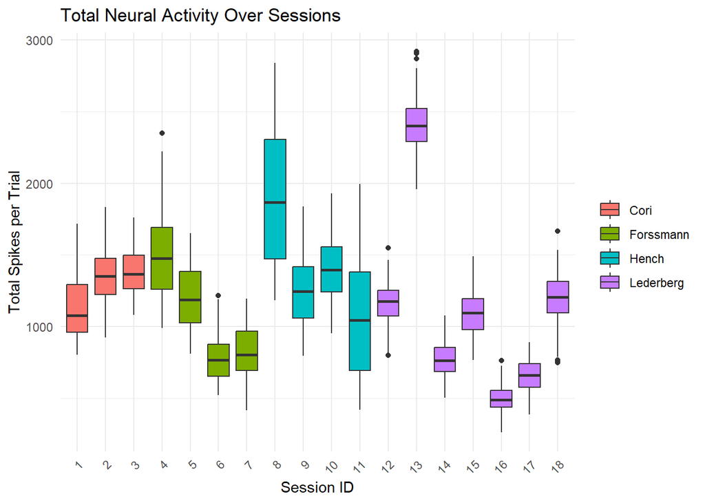

```r
all_trials_df <- map2_df(session, 1:18, function(session_data, session_id) {
  tibble(
    session_id = session_id,
    mouse_name = session_data$mouse_name[1],
    date_exp = session_data$date_exp[1],
    total_spikes = sapply(session_data$spks, sum)
  )
})

all_trials_df$date_exp <- as.Date(all_trials_df$date_exp)

all_trials_df <- all_trials_df %>% arrange(date_exp)

ggplot(all_trials_df, aes(x = as.factor(session_id), y = total_spikes, fill = mouse_name)) +
  geom_boxplot() +
  labs(title = "Total Neural Activity Over Sessions",
       x = "Session ID", y = "Total Spikes per Trial") +
  theme_minimal() +
  theme(axis.text.x = element_text(angle = 45, hjust = 1),
        legend.title = element_blank())
```

In the visualization of total neural activity over the 18 sessions, each mouse displayed distinctive patterns of engagement. The color coding distinctly separates the sessions affiliated with Cori (sessions 1-3), Forssmann (sessions 4-7), Hench (sessions 8-11), and Lederberg (sessions 12-18), allowing for a clear visual comparison across different phases of the experiment.

- Cori’s sessions show a increasing trend in total spikes per trial, suggesting that they were adapting to the task as time progressed.
- Forssmann’s and Hench’s trials, on the other hand show a decreasing and trend in total spikes per trial; this pattern could signify learning fatigue.
- Lederberg’s sessions, display demonstrated a more varied level of neural activity, indicating high variability in responding to the stimuli across sessions.

**Explore Changes Across Trials**

In this section we will explore neural activity across trials within each session.

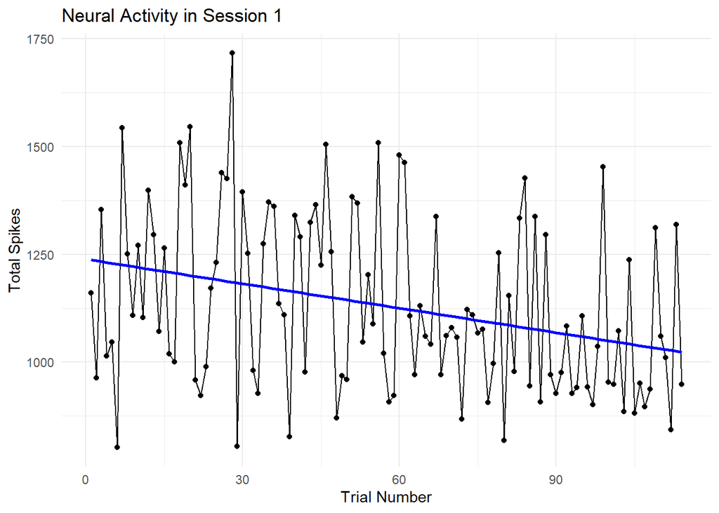

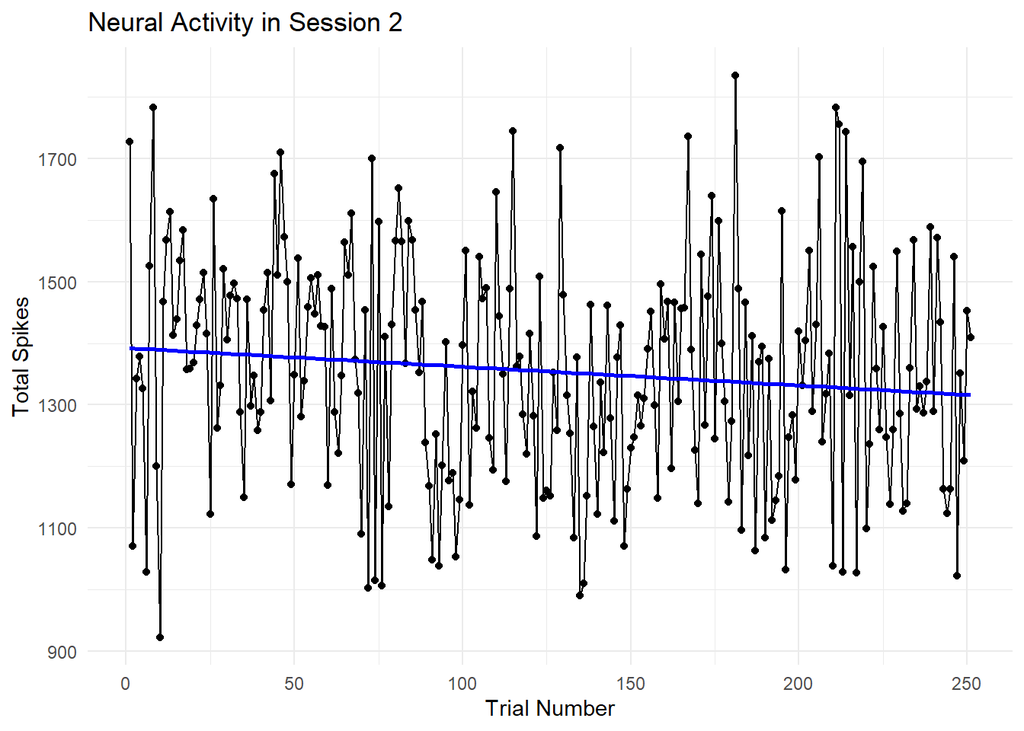

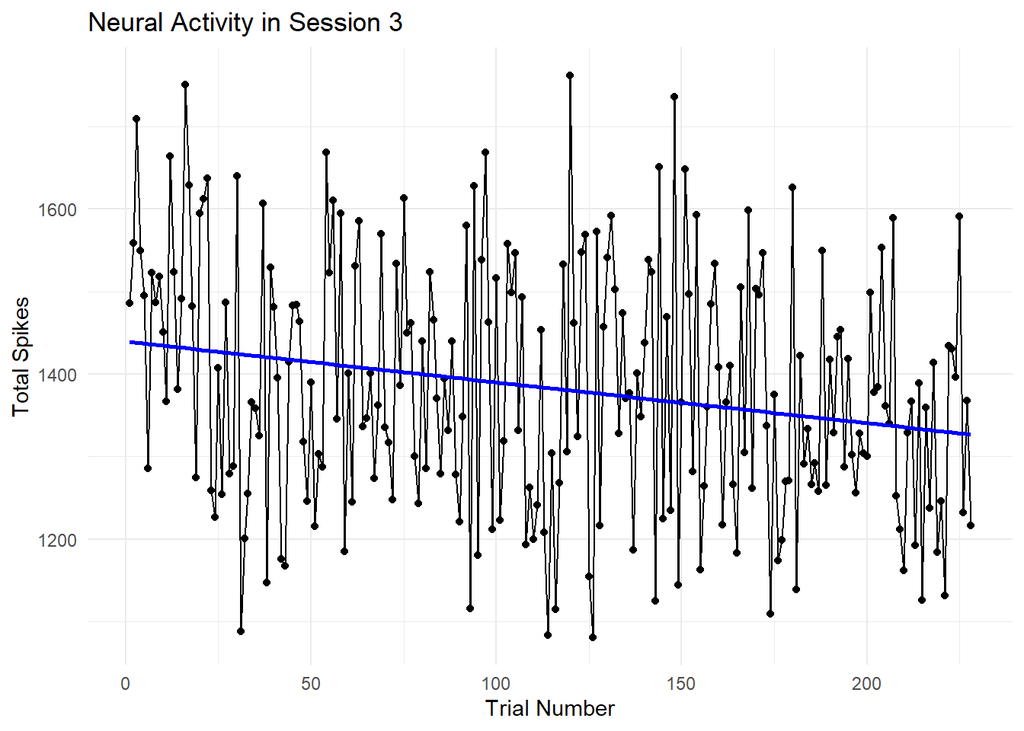

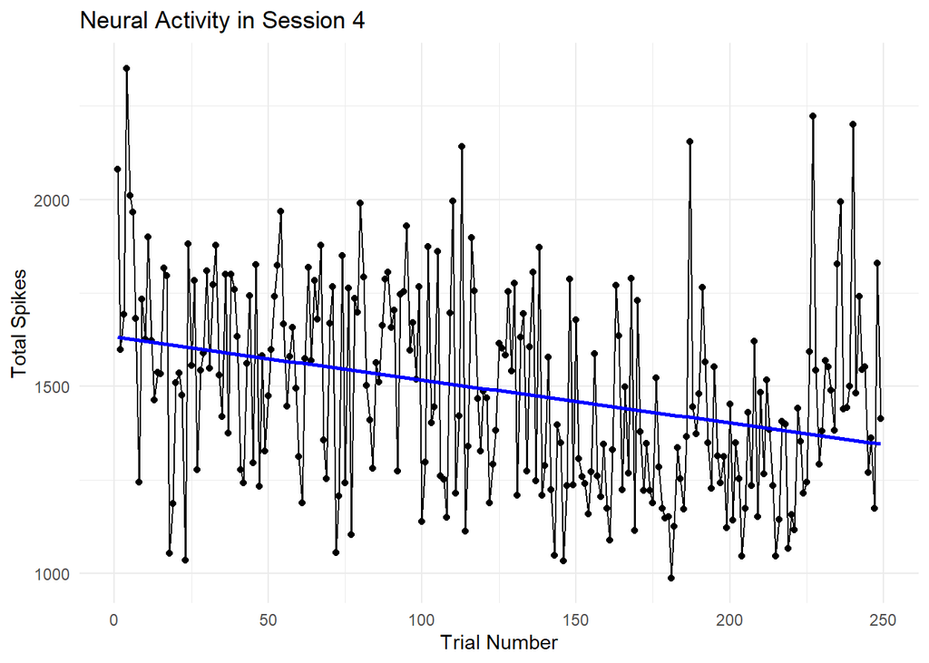

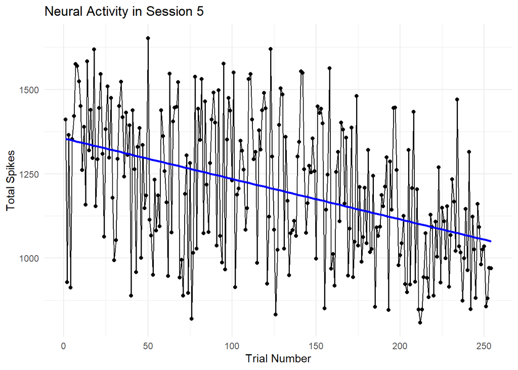

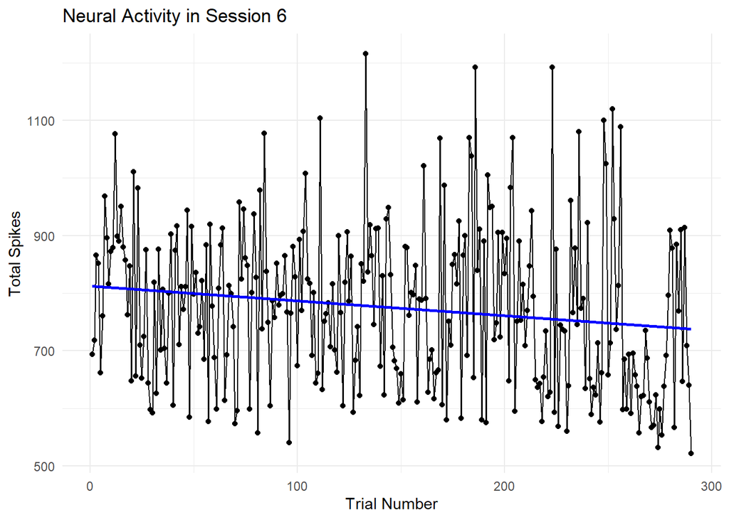

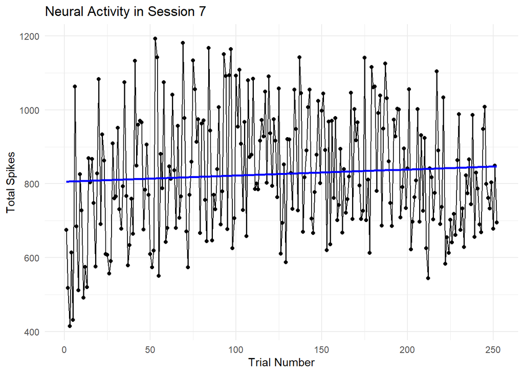

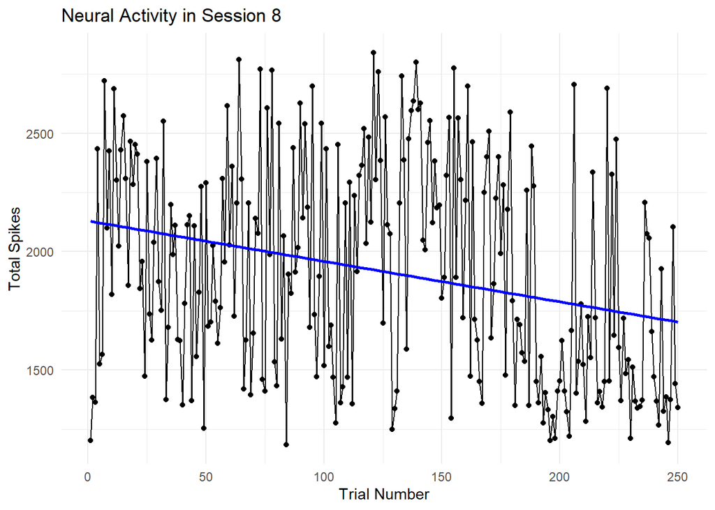

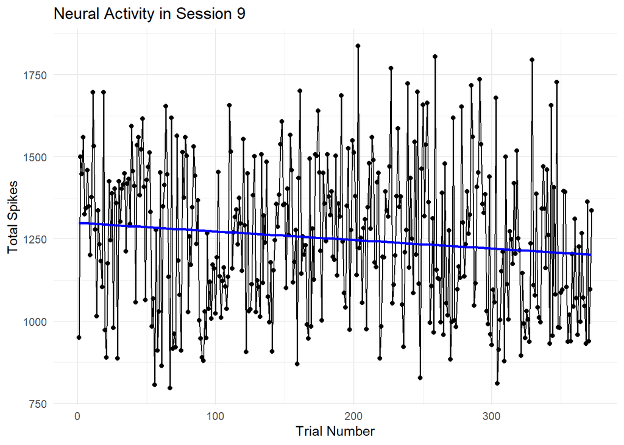

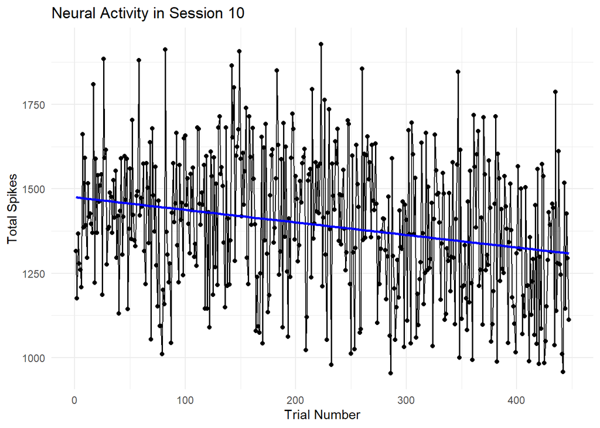

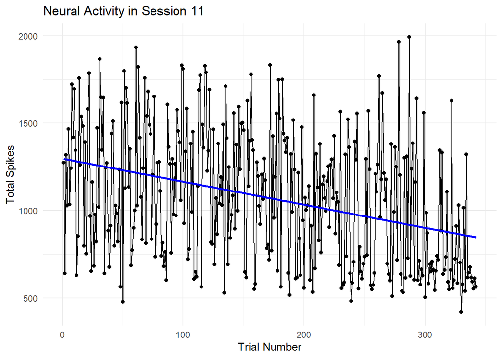

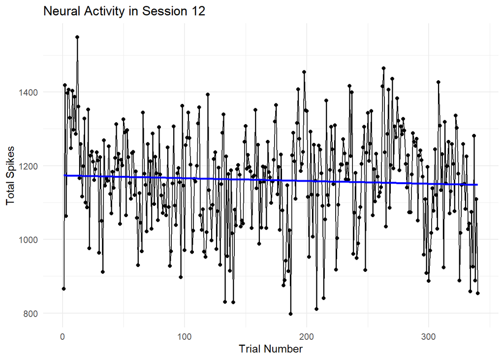

[6 more figures not shown]

```r
plot_session_activity <- function(session_data, session_number) {
  total_spikes_per_trial <- sapply(session_data$spks, function(trial) sum(trial))
  data_frame <- data.frame(trial = 1:length(total_spikes_per_trial), total_spikes = total_spikes_per_trial)

  p <- ggplot(data_frame, aes(x = trial, y = total_spikes)) +
    geom_line() +
    geom_point() +
    geom_smooth(method = "lm", se = FALSE, color = "blue") +
    labs(title = paste("Neural Activity in Session", session_number),
         x = "Trial Number",
         y = "Total Spikes") +
    theme_minimal()

  print(p)
}

for(i in 1:length(session)) {
  plot_session_activity(session[[i]], i)
}
```

In all sessions except for session 7, we observe a declining trend in neural activity across trials, as indicated by the line of best fit. This trend suggests that, generally, as trials progress within a session, the mouse’s neural engagement with the stimuli decreases.

**Exploring homogeneity and heterogeneity across sessions and mice**

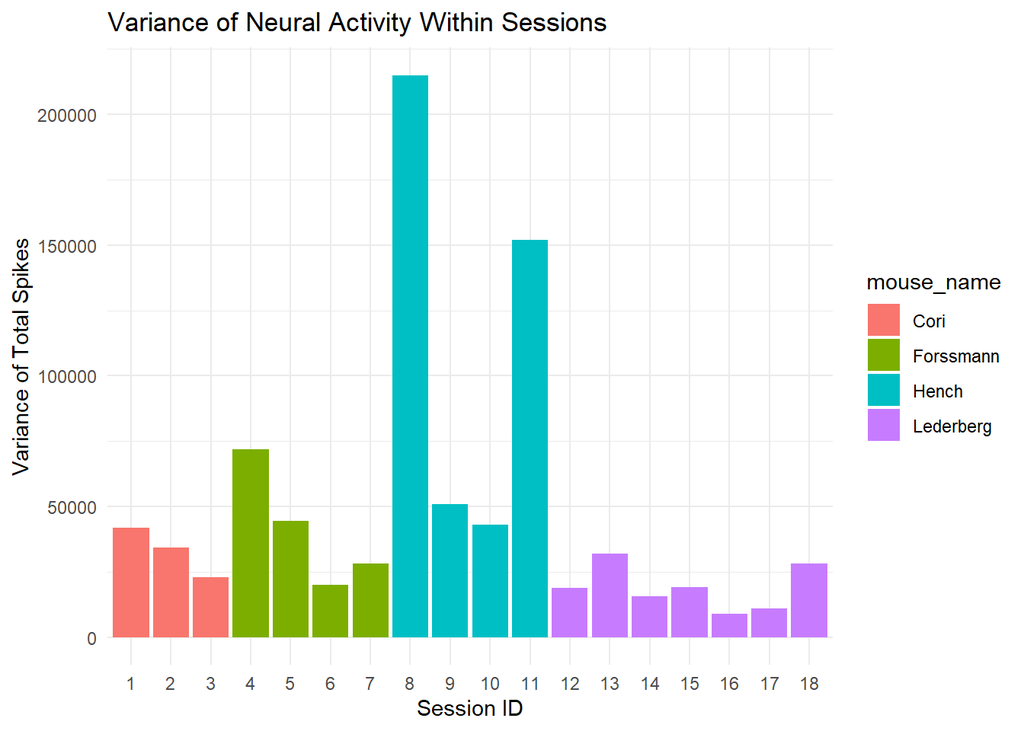

```r
calculate_total_spikes <- function(session) {
  sapply(session$spks, sum)
}

all_sessions_df <- do.call(rbind, lapply(1:length(session), function(i) {
  session_data <- session[[i]]
  data.frame(
    mouse_name = session_data$mouse_name,
    session_id = i,
    trial_id = 1:length(session_data$feedback_type),
    total_spikes = calculate_total_spikes(session_data),
    stringsAsFactors = FALSE
  )
}))

all_sessions_df %>%
  group_by(mouse_name, session_id) %>%
  summarise(variance = var(total_spikes), .groups = 'drop') %>%
  ggplot(aes(x = factor(session_id), y = variance, fill = mouse_name)) +
  geom_bar(stat = "identity", position = position_dodge()) +
  labs(title = "Variance of Neural Activity Within Sessions",
       x = "Session ID", y = "Variance of Total Spikes") +
  theme_minimal()
```

**Exploring homogeneity/heterogeneity within sessions**

The first plot, depicting the variance of total spikes within each session, shows that sessions from Hench exhibit high variability in neural activity. This suggests that within sessions, neural engagement varies greatly, indicating heterogeneity in the mouse’s response to stimuli across trials. However the other mice exibit relatively low variability in neural activity suggesting that within sessions, neural engagement varies greatly, indicating homogenity in the mouse’s response to stimuli across trials.

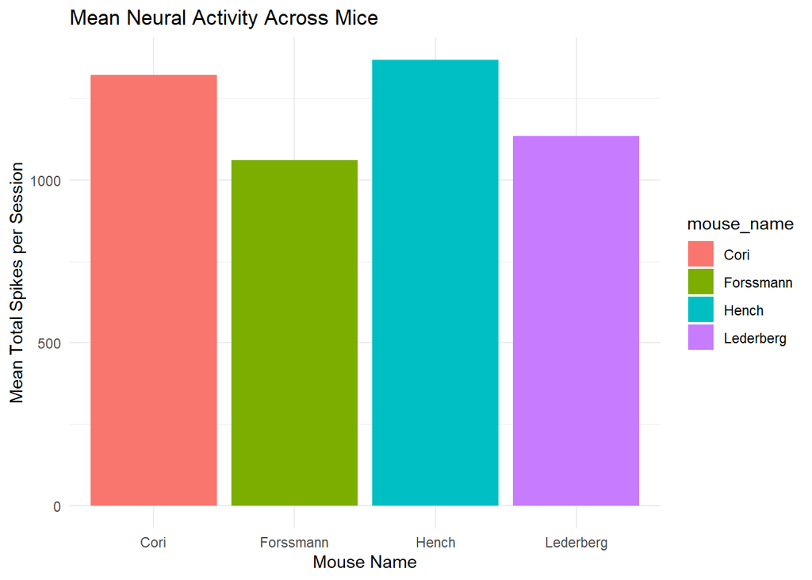

```r
all_sessions_df %>%
  group_by(mouse_name) %>%
  summarise(mean_spikes = mean(total_spikes), .groups = 'drop') %>%
  ggplot(aes(x = mouse_name, y = mean_spikes, fill = mouse_name)) +
  geom_bar(stat = "identity") +
  labs(title = "Mean Neural Activity Across Mice",
       x = "Mouse Name", y = "Mean Total Spikes per Session") +
  theme_minimal()
```

**Exploring homogeneity/heterogeneity between mice**

The second plot, comparing the mean total spikes per session for each mouse, indicates that the average neural activity across mice is close. Despite Forssmann showing slightly lower average activity, the differences in mean neural engagement between mice are relatively minimal. This observation suggests a level of homogeneity in how different mice respond to stimuli over the sessions, underscoring their comparable neural responsiveness.

```
## # A tibble: 6 × 49
##     bin1   bin2   bin3   bin4   bin5   bin6   bin7   bin8   bin9  bin10  bin11
##    <dbl>  <dbl>  <dbl>  <dbl>  <dbl>  <dbl>  <dbl>  <dbl>  <dbl>  <dbl>  <dbl>
## 1 0.0490 0.0368 0.0177 0.0150 0.0327 0.0286 0.0313 0.0123 0.0341 0.0191 0.0463
## 2 0.0300 0.0313 0.0341 0.0272 0.0259 0.0313 0.0218 0.0232 0.0232 0.0341 0.0272
## 3 0.0490 0.0504 0.0300 0.0436 0.0245 0.0409 0.0300 0.0381 0.0341 0.0422 0.0559
## 4 0.0559 0.0531 0.0272 0.0613 0.0572 0.0599 0.0450 0.0286 0.0395 0.0354 0.0368
## 5 0.0272 0.0436 0.0313 0.0245 0.0450 0.0381 0.0463 0.0572 0.0477 0.0163 0.0272
## 6 0.0490 0.0218 0.0163 0.0109 0.0123 0.0232 0.0272 0.0327 0.0163 0.0191 0.0300
## # ℹ 38 more variables: bin12 <dbl>, bin13 <dbl>, bin14 <dbl>, bin15 <dbl>,
## #   bin16 <dbl>, bin17 <dbl>, bin18 <dbl>, bin19 <dbl>, bin20 <dbl>,
## #   bin21 <dbl>, bin22 <dbl>, bin23 <dbl>, bin24 <dbl>, bin25 <dbl>,
## #   bin26 <dbl>, bin27 <dbl>, bin28 <dbl>, bin29 <dbl>, bin30 <dbl>,
## #   bin31 <dbl>, bin32 <dbl>, bin33 <dbl>, bin34 <dbl>, bin35 <dbl>,
## #   bin36 <dbl>, bin37 <dbl>, bin38 <dbl>, bin39 <dbl>, bin40 <dbl>,
## #   trial_id <int>, contrast_left <dbl>, contrast_right <dbl>, …
```

Using this newly formed table we can solve additional questions.

**What is the total number of successful trials in each session**

```
## # A tibble: 18 × 2
##    session_id successful_trials
##    <fct>                  <int>
##  1 1                         69
##  2 2                        159
##  3 3                        151
##  4 4                        166
##  5 5                        168
##  6 6                        215
##  7 7                        169
##  8 8                        161
##  9 9                        255
## 10 10                       277
## 11 11                       272
## 12 12                       251
## 13 13                       239
## 14 14                       186
## 15 15                       309
## 16 16                       201
## 17 17                       186
## 18 18                       174
```

**What is the average contrast difference in each session?**

```
## # A tibble: 18 × 2
##    session_id average_contrast_diff
##    <fct>                      <dbl>
##  1 1                          0.471
##  2 2                          0.458
##  3 3                          0.398
##  4 4                          0.355
##  5 5                          0.372
##  6 6                          0.363
##  7 7                          0.321
##  8 8                          0.545
##  9 9                          0.489
## 10 10                         0.448
## 11 11                         0.433
## 12 12                         0.393
## 13 13                         0.419
## 14 14                         0.396
## 15 15                         0.430
## 16 16                         0.430
## 17 17                         0.464
## 18 18                         0.417
```

**Question**

Given all this information, does the contrast difference have a causal relationship with feedback_type?

```
##                                        Df Sum Sq Mean Sq F value   Pr(>F)
## abs_contrast_diff                       1     81   81.31 103.528  < 2e-16 ***
## factor(session_id)                     17     90    5.27   6.711 3.31e-16 ***
## abs_contrast_diff:factor(session_id)   17     51    2.97   3.786 2.22e-07 ***
## Residuals                            5045   3962    0.79
## ---
## Signif. codes:  0 '***' 0.001 '**' 0.01 '*' 0.05 '.' 0.1 ' ' 1
```

**EDA Conclusion**

Stimuli conditions varied significantly across sessions, with contrast levels ranging approximately from 0.24 to 0.43. Feedback success rates were generally above chance, with Lederberg showing consistently high performance.

Neural activity trends across trials within sessions generally decreased, indicating a potential decrease in engagement or learning fatigue, except for session 7.

Homogeneity within sessions varied with Hench showing the highest variability in neural activity, suggesting heterogeneity in response to stimuli. Between mice, neural activity levels were relatively similar, indicating a level of homogeneity in neural responsiveness to stimuli across different mice.

# Data Integration

The information derived form the EDA conducted previously reveals several key insights about the mouse neural activities across sessions ans trials. Both similarities and differences were found in the neural response to stimuli among different mice.

In order to reduce the complexity of the data structures for better analysis, we can employ dimension reduction of the matrix representing the neural activity in the form of principal component analysis (PCA). We can then interpret the PCA in order to better understand relationships between sessions and between mice.

The goal of this data integration is enhance the prediction of feedback types based on neural activities.

**PCA**

**Session Specific**

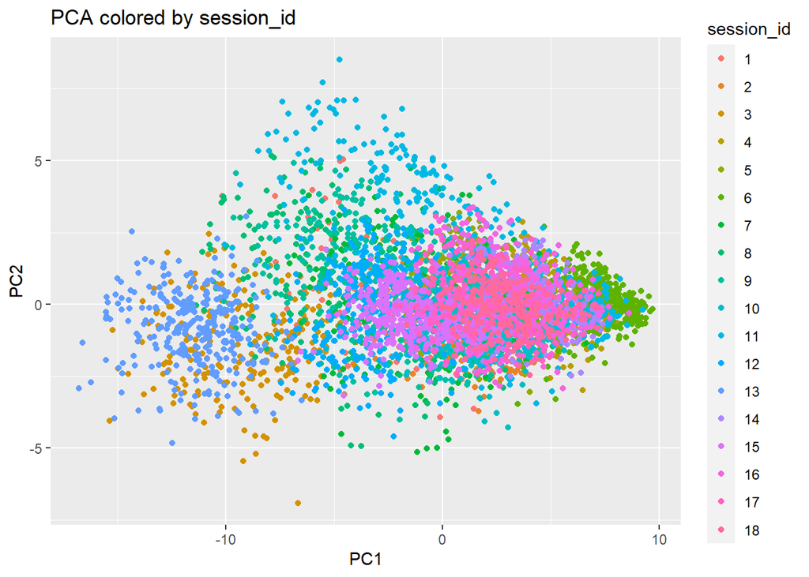

Different sessions contribute data spread across both components, with some clustering observable by session. This suggests that there might be session-specific variations in the dataset, as some sessions cluster together while others are more dispersed. ***

**Mouse Specific**

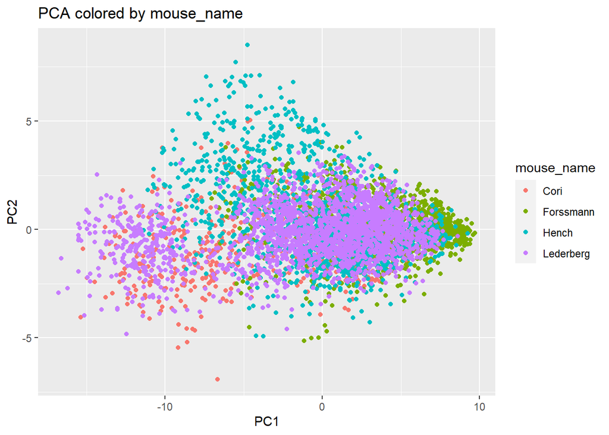

The overlap of colors in this PCA suggests that while there is some degree of distinct clustering per mouse, there’s also considerable overlap in the data points from different mice across PC1 and PC2. This could imply that individual differences between the mice may contribute to the variation, but not as distinctly as session-based differences that we have observed in the previous plot. ***

**Feature Extraction**

We will prepare the following features to predict the outcome (feedback_type): - contrast_left - contrast_right - contrast_diff

```r
predictive_feature <- c("session_id", "trial_id", "contrast_right", "contrast_left", "contrast_diff", binename)
predictive_dat <- training_tibble[predictive_feature]
predictive_dat$trial_id <- as.numeric(predictive_dat$trial_id)
label <- as.numeric(training_tibble$success)
X <- model.matrix(~ ., predictive_dat)
head(X)
```

```
##   (Intercept) session_id2 session_id3 session_id4 session_id5 session_id6
## 1           1           0           0           0           0           0
## 2           1           0           0           0           0           0
## 3           1           0           0           0           0           0
## 4           1           0           0           0           0           0
## 5           1           0           0           0           0           0
## 6           1           0           0           0           0           0
##   session_id7 session_id8 session_id9 session_id10 session_id11 session_id12
## 1           0           0           0            0            0            0
## 2           0           0           0            0            0            0
## 3           0           0           0            0            0            0
## 4           0           0           0            0            0            0
## 5           0           0           0            0            0            0
## 6           0           0           0            0            0            0
##   session_id13 session_id14 session_id15 session_id16 session_id17 session_id18
```

[output cut: 55 more lines]

# Prediction

**Test/Train split 9:1**

Train Model:

**Prediction results**

Accuracy:

```
## [1] 0.7244094
```

Confusion Matrix:

```
##           Reference
## Prediction   0   1
##          0  35  44
##          1  96 333
```

Area Under Reporter Operating Curve:

```
##
## Call:
## roc.default(response = test_label, predictor = predictions)
##
## Data: predictions in 131 controls (test_label 0) < 377 cases (test_label 1).
## Area under the curve: 0.678
```

# Prediction Performance on the Test Sets

Load Data:

```r
test <- list()
for (i in 1:2) {
  test[[i]] <- readRDS(paste('data/test/test', i, '.rds', sep = ''))
}
```

Setup Inference Df:

```
## # A tibble: 6 × 49
##     bin1   bin2   bin3   bin4   bin5   bin6   bin7   bin8   bin9  bin10  bin11
##    <dbl>  <dbl>  <dbl>  <dbl>  <dbl>  <dbl>  <dbl>  <dbl>  <dbl>  <dbl>  <dbl>
## 1 0.0327 0.0259 0.0232 0.0259 0.0300 0.0286 0.0327 0.0450 0.0436 0.0272 0.0327
## 2 0.0354 0.0354 0.0381 0.0272 0.0341 0.0518 0.0477 0.0341 0.0327 0.0232 0.0259
## 3 0.0354 0.0313 0.0245 0.0327 0.0204 0.0136 0.0300 0.0313 0.0272 0.0395 0.0490
## 4 0.0341 0.0259 0.0422 0.0259 0.0232 0.0409 0.0463 0.0422 0.0395 0.0327 0.0368
## 5 0.0313 0.0300 0.0218 0.0518 0.0695 0.0463 0.0300 0.0163 0.0232 0.0204 0.0450
## 6 0.0490 0.0436 0.0341 0.0463 0.0409 0.0381 0.0490 0.0381 0.0409 0.0313 0.0368
## # ℹ 38 more variables: bin12 <dbl>, bin13 <dbl>, bin14 <dbl>, bin15 <dbl>,
## #   bin16 <dbl>, bin17 <dbl>, bin18 <dbl>, bin19 <dbl>, bin20 <dbl>,
## #   bin21 <dbl>, bin22 <dbl>, bin23 <dbl>, bin24 <dbl>, bin25 <dbl>,
## #   bin26 <dbl>, bin27 <dbl>, bin28 <dbl>, bin29 <dbl>, bin30 <dbl>,
## #   bin31 <dbl>, bin32 <dbl>, bin33 <dbl>, bin34 <dbl>, bin35 <dbl>,
## #   bin36 <dbl>, bin37 <dbl>, bin38 <dbl>, bin39 <dbl>, bin40 <dbl>,
## #   trial_id <int>, contrast_left <dbl>, contrast_right <dbl>, …
```

**Test Model Performance**

Below will be the tests for sets test1.rds and test2.rds (sessions 1 and 18).

```
##   (Intercept) session_id2 session_id3 session_id4 session_id5 session_id6
## 1           1           0           0           0           0           0
## 2           1           0           0           0           0           0
## 3           1           0           0           0           0           0
## 4           1           0           0           0           0           0
## 5           1           0           0           0           0           0
## 6           1           0           0           0           0           0
##   session_id7 session_id8 session_id9 session_id10 session_id11 session_id12
## 1           0           0           0            0            0            0
## 2           0           0           0            0            0            0
## 3           0           0           0            0            0            0
## 4           0           0           0            0            0            0
## 5           0           0           0            0            0            0
## 6           0           0           0            0            0            0
##   session_id13 session_id14 session_id15 session_id16 session_id17 session_id18
```

[output cut: 55 more lines]

```
##   (Intercept) session_id2 session_id3 session_id4 session_id5 session_id6
## 1           1           1           0           0           0           0
## 2           1           1           0           0           0           0
## 3           1           1           0           0           0           0
## 4           1           1           0           0           0           0
## 5           1           1           0           0           0           0
## 6           1           1           0           0           0           0
##   session_id7 session_id8 session_id9 session_id10 session_id11 session_id12
## 1           0           0           0            0            0            0
## 2           0           0           0            0            0            0
## 3           0           0           0            0            0            0
## 4           0           0           0            0            0            0
## 5           0           0           0            0            0            0
## 6           0           0           0            0            0            0
##   session_id13 session_id14 session_id15 session_id16 session_id17 session_id18
```

[output cut: 55 more lines]

**Test test1.rds (Session 1)**

```
## Accuracy for test 1 (session 1): 0.72
```

```
## Confusion Matrix and Statistics
##
##           Reference
## Prediction  0  1
##          0  5  5
##          1 23 67
##
##                Accuracy : 0.72
##                  95% CI : (0.6213, 0.8052)
##     No Information Rate : 0.72
##     P-Value [Acc > NIR] : 0.550711
##
##                   Kappa : 0.1358
##
##  Mcnemar's Test P-Value : 0.001315
##
##             Sensitivity : 0.1786
##             Specificity : 0.9306
##          Pos Pred Value : 0.5000
##          Neg Pred Value : 0.7444
##              Prevalence : 0.2800
##          Detection Rate : 0.0500
##    Detection Prevalence : 0.1000
##       Balanced Accuracy : 0.5546
##
##        'Positive' Class : 0
##
```

```
## AUC for test 1 (session 1): 0.6800595
```

**Test test2.rds (Session 18)**

```
## Accuracy for test 2 (session 18): 0.75
```

```
## Confusion Matrix and Statistics
##
##           Reference
## Prediction  0  1
##          0  4  2
##          1 23 71
##
##                Accuracy : 0.75
##                  95% CI : (0.6534, 0.8312)
##     No Information Rate : 0.73
##     P-Value [Acc > NIR] : 0.3737
##
##                   Kappa : 0.1599
##
##  Mcnemar's Test P-Value : 6.334e-05
##
##             Sensitivity : 0.1481
##             Specificity : 0.9726
##          Pos Pred Value : 0.6667
##          Neg Pred Value : 0.7553
##              Prevalence : 0.2700
##          Detection Rate : 0.0400
##    Detection Prevalence : 0.0600
##       Balanced Accuracy : 0.5604
##
##        'Positive' Class : 0
##
```

```
## AUC for test 2 (session 18): 0.6737697
```

# Discussion

In summary, my study confirms the influence of contrast differences on feedback type, with individual variations in neural and behavioral responses to visual stimuli.

# Reference

Steinmetz, N.A., Zatka-Haas, P., Carandini, M. et al. Distributed coding of choice, action and engagement across the mouse brain. Nature 576, 266–273 (2019). https://doi.org/10.1038/s41586-019-1787-x